# Time Series Analysis

### Section 4

#### Cluster ads into 3 groups based on trends in avg. cost per click

#### Section 4.1

First let us visualize the avg. cost per click by each ad group as a time-series.

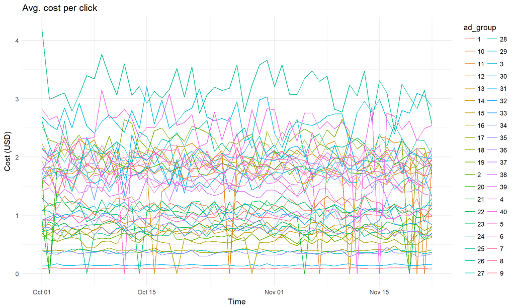

```r
# Use the original ad table to get date, ads shown and ad group.
copy_at6 = subset(ad_table, select = c(date, avg_cost_per_click, ad_group))

# Visualize the current ad views trends by ad group
df7 = melt(copy_at6, id.vars="date", measure.vars="avg_cost_per_click", variable.name = "ad_group")
df7$ad_group = as.character(copy_at6$ad_group)
gg = ggplot(df7, aes(x=date, y=value, colour=ad_group, group=ad_group)) +
    geom_line() +
    theme_minimal() +
    labs(title="Avg. cost per click", x="Time", y = "Cost (USD)")
gg
```

#### Section 4.2

The above chart looks similar to the ads shown series but the cost fluctuations are more.  
We will use the same imputation strategy used for *shown*, this will help to have contiguous data. We can then smoothen the data to see trends.

```r
# Find the ad groups and their indices where views are zero
copy_at6 = subset(ad_table, select = c(date, avg_cost_per_click, ad_group))

# Find dates
ad_list = unique(copy_at6$ad_group)
prev_dates = 0
mis_grps = c()
for(ad in ad_list) {
  dates = length(copy_at6[copy_at6$ad_group == ad, "date"])
  if(dates < prev_dates) {
    mis_grps = c(mis_grps, ad)
  }
  prev_dates = dates
}
cat("\nAd groups with missing dates are -", mis_grps)
```

```
##
## Ad groups with missing dates are - 10 14 18 20 24
```

```r
# Setup a default list of dates
def_dates = as.Date(copy_at6[copy_at6$ad_group == 1, "date"])
# Get the groups with missing dates
# Find the missing date (these groups are only missing one date)
# Insert the missing date
for(mis in mis_grps) {
  mis_dates = as.Date(copy_at6[copy_at6$ad_group == mis, "date"])
  mdate = as.Date(setdiff(def_dates, mis_dates), origin = "1970-01-01")
  ins_df = data.frame(date = mdate, avg_cost_per_click = 0, ad_group = mis)
  copy_at6 = rbind(copy_at6, ins_df)
}

# Order by ad and date
copy_at6 = copy_at6[order(copy_at6[,3], copy_at6[,1] ), ]

# Fix avg. cost
zero_list = copy_at6[copy_at6$avg_cost_per_click == 0, "ad_group"]
index_list = which(copy_at6$avg_cost_per_click == 0)
cat("\nNo. of times cost was zero originally:", length(zero_list))
```

```
##
## No. of times cost was zero originally: 25
```

```r
# Impute the zero cost with avg. cost for each ad group
# If an ad group is repeated, use a single avg. value to impute
counter = 1
prev_ad = 0
prev_impt = 0
for(ad in zero_list) {
  if(ad == prev_ad) {
    copy_at6$avg_cost_per_click[index_list[counter]] = prev_impt
  }
  else {
    cost = copy_at6[copy_at6$ad_group == ad, "avg_cost_per_click"]
    prev_impt = round(mean(cost), 2)
    copy_at6$avg_cost_per_click[index_list[counter]] = prev_impt
    prev_ad = ad
  }
  counter = counter + 1
}

zero_list = copy_at6[copy_at6$avg_cost_per_click == 0, "ad_group"]
cat("\nNo. of times cost is zero after imputation:", length(zero_list))
```

```
##
## No. of times cost is zero after imputation: 0
```

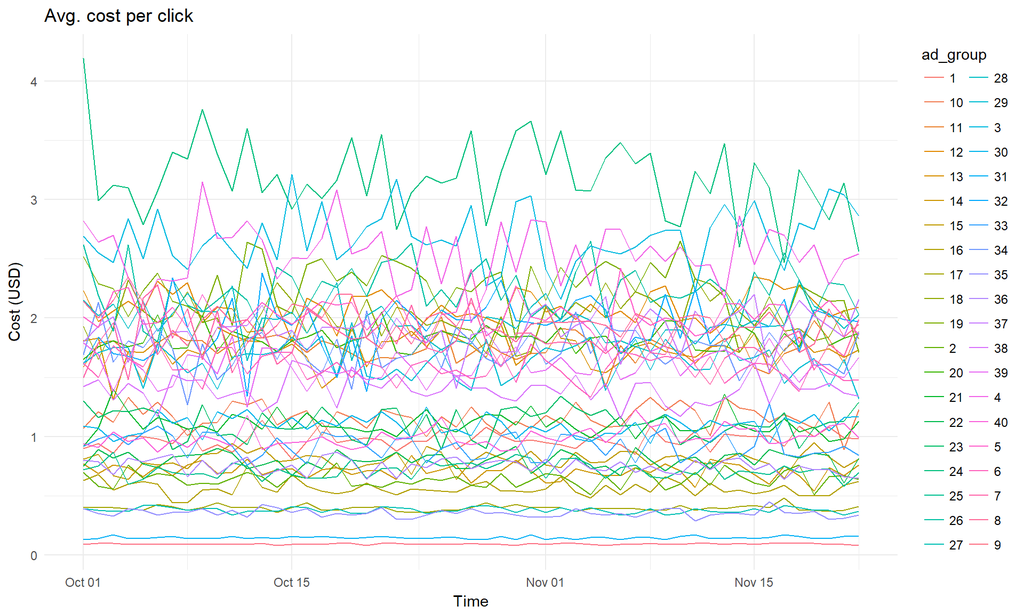

```r
# Visualize the changes
df8 = melt(copy_at6, id.vars="date", measure.vars="avg_cost_per_click", variable.name = "ad_group")
df8$ad_group = as.character(copy_at6$ad_group)

gh = ggplot(df8, aes(x=date, y=value, colour=ad_group, group=ad_group)) +
    geom_line() +
    theme_minimal() +
    labs(title="Avg. cost per click", x="Time", y = "Cost (USD)")
gh
```

#### Section 4.3

**Smoothen data**

We will calculate a 7-day/weekly moving average of the avg. click cost to smoothen the data first.

```r
library(forecast)
library(tseries)
copy_at6$date = as.Date(copy_at6$date)

# Since there is data only for about 2 months, we will calculate a weekly moving average
ad_list = unique(copy_at4$ad_group)
copy_at6$cost_ma = NA
for(ad in ad_list) {
  copy_at6[copy_at6$ad_group == ad, "cost_ma"] = ma(copy_at6[copy_at6$ad_group == ad, "avg_cost_per_click"], order=7)
}

cat("No. of missing values in moving avg.-", sum(is.na(copy_at6$cost_ma)))
```

```
## No. of missing values in moving avg.- 240
```

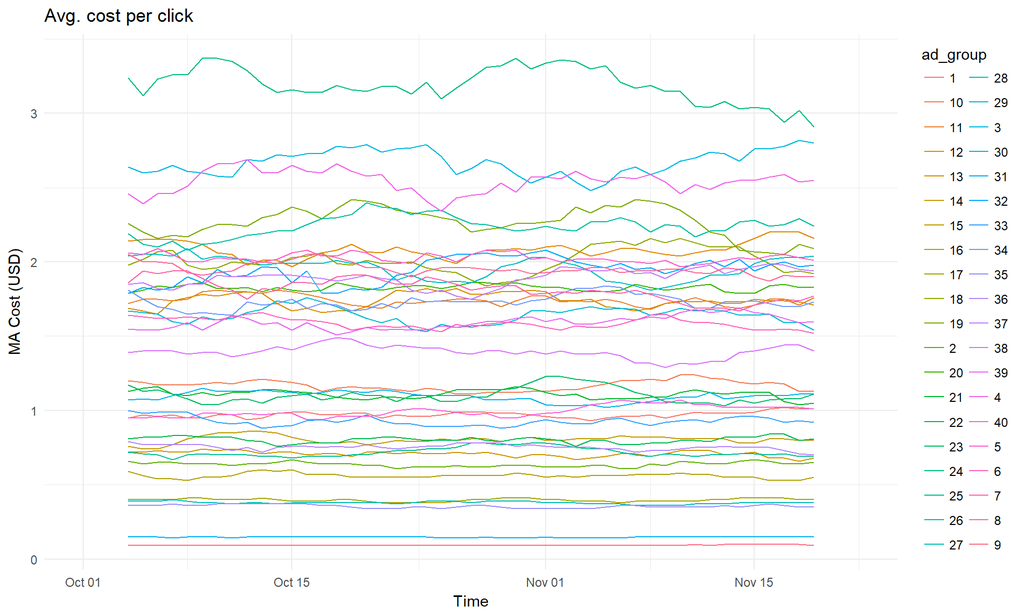

```r
# Round the MAs
copy_at6$cost_ma = round(copy_at6$cost_ma, 2)

# Visualize the changes
df6 = melt(copy_at6, id.vars="date", measure.vars="cost_ma", variable.name = "ad_group")
df6$ad_group = as.character(copy_at6$ad_group)

gi = ggplot(df6, aes(x=date, y=value, colour=ad_group, group=ad_group)) +
    geom_line() +
    theme_minimal() +
    labs(title="Avg. cost per click", x="Time", y = "MA Cost (USD)")
gi
```

#### Section 4.4

**Based on trends group data into up, down and flat categories**

We add an additional 4th category called *Mixed* if the trend is not clear.  
We will use the moving average to find the trend in each ad group.

```r
direction = function(x) {
  upt = length(which(diff(x) > 0))
  dwnt = length(which(diff(x) < 0))
  fltt = length(which(diff(x) == 0))
  # If 65% of data is in a particular direction then set the trend
  if(upt >= 26)
    return("Upward")
  else if(dwnt >= 26)
    return("Downward")
  else if(fltt >= 26)
    return("Flat")
  else if(upt == dwnt)  # If up and down are equal then consider as flat
    return("Flat")
  else
    return("Mixed")
}

trend_df = data.frame(ad_group=NA, trend=NA)
for(ad in ad_list) {
  # The moving average smoothed the data such that there is no clear trend
  # Most groups are falling under the Mixed category
  # trend = direction(copy_at6[copy_at6$ad_group == ad, "cost_ma"])

  # Using the original click cost
  trend = direction(copy_at6[copy_at6$ad_group == ad, "avg_cost_per_click"])
  trend_df[ad, ] = c(ad, trend)
}
trend_df = na.omit(trend_df)

trend_list = c("Upward", "Downward", "Flat", "Mixed")
cat("\nThe ad groups with the four click cost trends are given below\n")
```

```
##
## The ad groups with the four click cost trends are given below
```

```r
for(trend in trend_list) {
  cat(trend, "-", trend_df[trend_df$trend == trend, "ad_group"], "\n")
}
```

```
## Upward - 3 4 7 11 12 15 20 22 23 24 25 29 33 34 37 40
## Downward - 1 2 5 6 10 13 18 19 21 26 28 30 32 36 38 39
## Flat -
## Mixed - 8 9 14 16 17 27 31 35
```

- We saw that using the moving average was not helpful in this case as most of the ad groups fell into the Mixed category.
- Using the avg_cost_per_click helped us to obtain more clear trends.